# Calculus

빅데이터분석실무 4주차

ssongplay

2021-10-26

# 수치 미분 개념 (유한 차분)

- 미분과 적분은 서로 연결된 개념
- 원시함수 > 미분 > 도함수
- 도함수 > 적분 > 원시함수
- 수치 미분은 특정 함수 f(x)의 한 점에서 그 함수와 만나는 접선의 기울기를 구하는 것
- 즉, 유한 차분 (finite difference)를 구한 다음, 차분의 구간이나 step size를 작게 함으로써 (h->0에 가깝도록) 구함
- 미분이란 결국, 유한 차분을 이해함에서 시작

  ```r
  fd = function(f, x, h = x*sqrt(.Machine$double.eps)){ # 작은 h
    return((f(x+h)-f(x))/h)  # 전진차분
  }
  ```

- 구간이 좁아질수록, 좀 더 디테일한 근사값을 추론 가능!

### Example

- f(x) = -x^2 + 6x – 6이라는 함수가 있을 때, x = 2에서의 접선 기울기는 ?

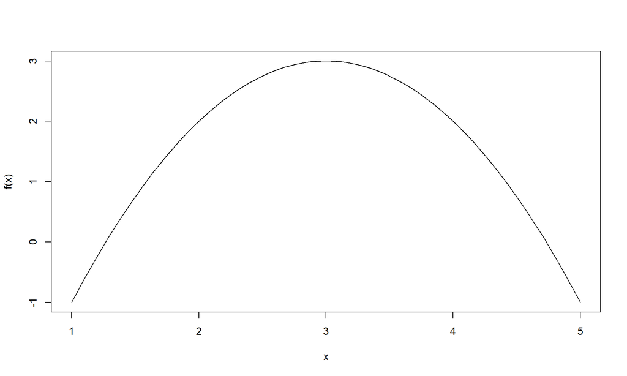

```r
f = function(x) - x^2 + 6*x - 6
curve(f,1,5)
```

```r
fd(f, 2, h = 1)
```

```
## [1] 1
```

```r
fd(f, 2, h = .5)
```

```
## [1] 1.5
```

```r
fd(f, 2, h = .1)
```

```
## [1] 1.9
```

```r
fd(f, 2, h = .1e-6)
```

```
## [1] 2
```

- 함수를 미분하면 -2x + 6이고 미분값은 2, 실제 h가 작을수록 차분값은 정확한 값에 근사함
- 왜 이런것을 알아야 할까? > 데이터분석/ 머신러닝의 핵심 개념인 “최적화”를 이해하기 위함

# 그냥 미분하기

- 일전의 함수인 –x^2+6x-6 을 한번 더 써먹자
- `expression` 함수와 `D` 함수를 활용

```r
fx = expression(-x^2 +6*x -6, "x")
dfx = D(fx, 'x')
dfx
```

```
## 6 - 2 * x
```

- X에 대해 미분!
- 2를 대입하여 미분값 산출 (eval 함수 활용)

```r
f <- function(x) eval(c(dfx)[[1]])
f(2)
```

```
## [1] 2
```

# 더 복잡한 함수 미분하기

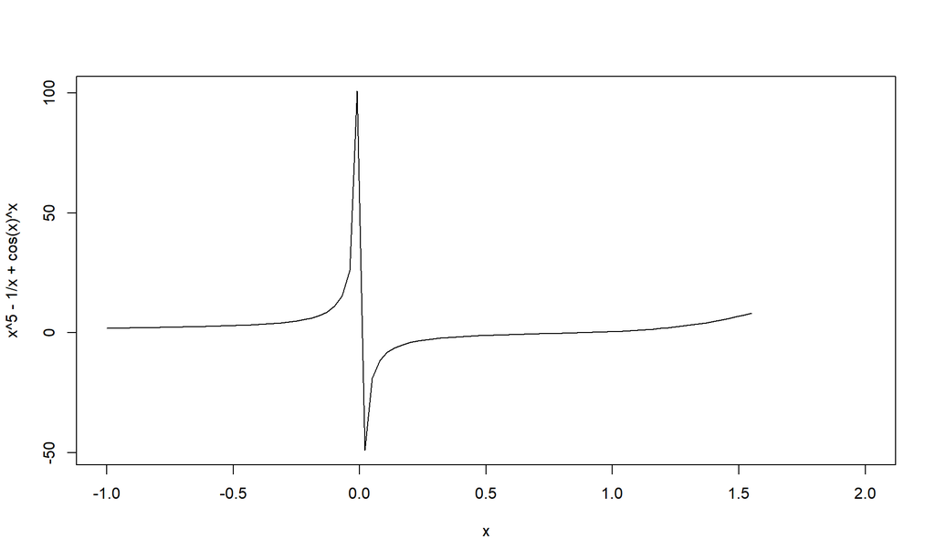

```r
fx = expression(x^5 -1/x + cos(x)^x,'x')
curve(x^5 -1/x + cos(x)^x, -1, 2)
```

```r
D(fx, "x")
```

```
## 5 * x^4 + 1/x^2 + (cos(x)^x * log(cos(x)) - cos(x)^(x - 1) *
##     (x * sin(x)))
```

- 다변수 함수 (x, y, z…)의 미분은 `deriv` 함수 활용

```r
fxyz = expression((x*y)^5 - 1/x^z + cos(x)^x)
exp = deriv(fxyz, c("x", "y", "z"))
exp
```

```
## expression({
##     .expr1 <- x * y
##     .expr3 <- x^z
##     .expr6 <- cos(x)
##     .expr7 <- .expr6^x
##     .expr9 <- .expr1^4
##     .expr15 <- .expr3^2
##     .value <- .expr1^5 - 1/.expr3 + .expr7
##     .grad <- array(0, c(length(.value), 3L), list(NULL, c("x",
##         "y", "z")))
##     .grad[, "x"] <- 5 * (y * .expr9) + x^(z - 1) * z/.expr15 +
##         (.expr7 * log(.expr6) - .expr6^(x - 1) * (x * sin(x)))
##     .grad[, "y"] <- 5 * (x * .expr9)
##     .grad[, "z"] <- .expr3 * log(x)/.expr15
##     attr(.value, "gradient") <- .grad
##     .value
## })
```

```r
f2 = function(x,y,z) eval(c(exp))
f2(1,1,1)
```

```
## [1] 0.5403023
## attr(,"gradient")
##             x y z
## [1,] 4.825905 5 0
```

# 적분의 개념과 활용

- 정적분 (범위가 정해진 경우)
- $$\frac{d}{dx}F(x) = f(x)$$
- 부정적분 (원시함수로의 회귀)
- $$\int_{a}^b f(x)dx$$
- 접선의 기울기를 찾으려는 미분과는 달리 f(x)의 면적을 추론
- 왜 면적을 구해야 할까? -> 향후 확률계산의 핵심이 바로 면적 추론에 있기 때문!
- ex) 표준정규분포에서의 밀도함수 기반으로 확률을 계산
- `Integrate` 함수 활용

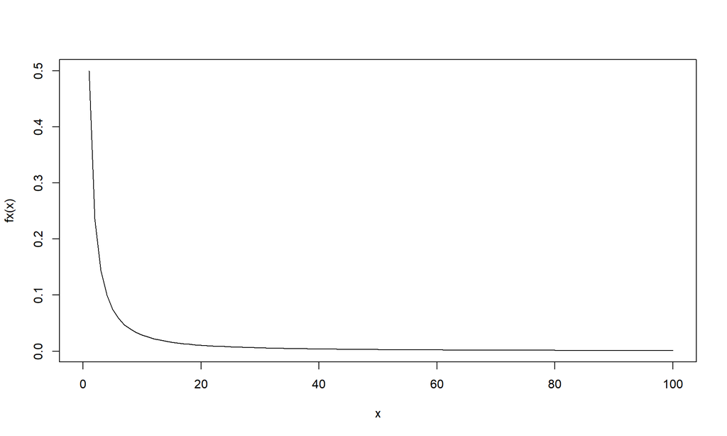

```r
fx = function(x) 1/ ((x+1)*sqrt(x))
curve(fx, 0, 100)
```

```r
integrate(fx, lower=0, upper=Inf)
```

```
## 3.141593 with absolute error < 2.7e-05
```

# 직사각형법

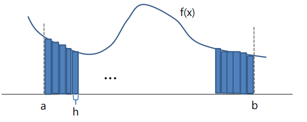

- 적분의 개념은 사각형을 최대한 촘촘히 만들어 해당 f(x)를 꽉 채우는 것
- 높이와 밑변을 곱해서 사각형의 넓이를 구하고 순차적으로 다 더하면 끝 !
- 직사각형을 활용한 적분 함수를 짜보자 !
- 쉽다 for문을 이용하면서 f(x)에다가 하나씩 집어 넣어보자!

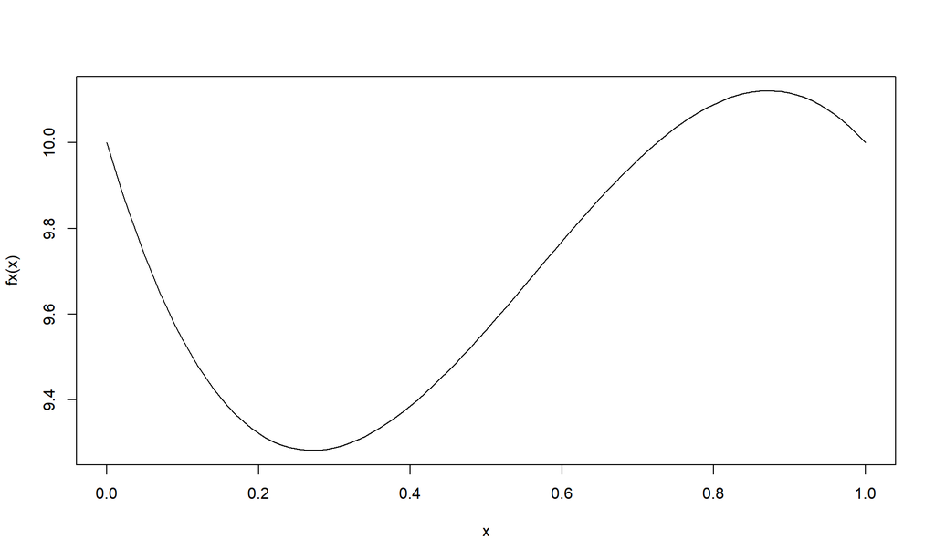

```r
fx = function(x) x^4 - 10*x^3 + 15*x^2 - 6*x + 10
curve(fx)
```

```r
# x^4 - 10x^3 -6x + 10이라는 함수가 있을 때, 0~1까지 적분한다면?

Integr_by_song = function(from, to, N){
  sum = 0         # 처음에는 0으로
  h = (to - from)/N     # 전체구간(1~0)을 n개로 나누면 직사각형 밑변의 길이 산출
  for (i in 1:N) sum = sum + h * fx(from + i*h)  #오른쪽 직사각형으로 가면서 높이 f(x)와 h를 곱해가며 더함
  return(sum)
}
```

```r
Integr_by_song(0, 1, 10)
```

```
## [1] 9.70333
```

```r
integrate(fx, 0, 1)
```

```
## 9.7 with absolute error < 1.1e-13
```

# 시뮬레이션을 활용한 수치 적분 소개

- 사실 어떤 현상이 깔끔하게 적분으로 계산되기는 굉장히 어렵다 (미분도 사실 마찬가지)
- 무식해 보이지만 굉장히 실용적인 방법이 있다 > 그건 바로 “시뮬레이션”
- f(x) = x^2이란 함수가 있을때 이 함수를 -2~2까지 적분해 보자

```r
fx = function(x) x^2
integrate(fx, -2, 2)
```

```
## 5.333333 with absolute error < 5.9e-14
```

```r
# 시뮬레이션으로 했을 때

set.seed(132)
a = -2
b = 2
c = 0
d = 4
n = 10^5

# x = -2~2, y = 0~4 까지의 영역에서 random으로 데이터 생성
x = runif(n, a, b)
y = runif(n, c, d)

# y값이 f(x)보다 작은 케이스를 전체 케이스에서 나눠줌
temp = sum(y<fx(x))/n
16*temp
```

```
## [1] 5.32832
```